# TeoNAM STAM — MLM (Q+K) GWAS on the authentic 118K panel (Fig 4C)

Chen’s actual Fig-4C mixed model (Q = 5 PCs + K = Centered-IBS, P3D) on the 118,838-SNP panel — scatter preserved, no densification

Author

Fausto Rodríguez-Zapata

Published

July 10, 2026

**What this is.** The GWAS model Chen 2019 actually used for **Fig 4C** — a linear **mixed model** with population structure (Q) and kinship (K) — run in TASSEL5 on the **authentic 118,838-SNP GWAS panel** (Qiuyue Chen’s Drive release, lifted to v5, 118,514 markers), and contrasted with the fixed-effect **OLS** scan (`teonam-stam-ols-gwas-118k`).

Crucially, this panel is only **~2.7% missing** (Chen’s MR < 0.2 GWAS SNPs), so the MLM runs **directly on it — no densification / step-interpolation**. That preserves the natural per-SNP **scatter** of a real GWAS Manhattan. This is the faithful Fig-4C reproduction that the interpolated 51K MLM notebook (`teonam-stam-mlm-gwas-interpolated`) could not be: there, the 73%-missing 51K **map** panel had to be step-interpolated to a complete matrix, which made genotypes block-constant → a **terraced/plateau** Manhattan and a spurious **over-correction** (kinship absorbing each QTL’s own-chromosome signal). Here, with the real GWAS panel, neither artifact applies. Compute lives in `scripts/teonam_mlm118k.R`; this notebook loads, documents, and plots.

```r
library(here)
library(data.table)
library(ggplot2)
theme_set(theme_bw(base_size = 13))
LOD <- 5 # Chen 2019 significance line: P < 1e-5

# genomic inflation factor: median(chi^2_obs) / median(chi^2_null)
lambda_gc <- function(p) {
  p <- p[is.finite(p) & p > 0 & p <= 1]
  round(median(qchisq(p, df = 1, lower.tail = FALSE)) / qchisq(0.5, df = 1), 3)
}
```

## The model

The OLS notebook fit fixed effects only: $y_i = \mu + \sum_f \beta_f\,\mathbb{1}[\text{family}_i=f] + \gamma\,g_{im} + \varepsilon_i$. Chen’s GWAS adds a polygenic **random** term with covariance $\mathbf K$ (Yu et al. 2006):

$$\mathbf{y} = \mathbf{1}\mu + \mathbf{Q}\boldsymbol{\alpha}
+ \mathbf{g}_a\,\gamma_a + \mathbf{g}_d\,\gamma_d
+ \mathbf{Z}\mathbf{u} + \boldsymbol{\varepsilon},
\qquad
\mathbf{u}\sim N(\mathbf 0,\,\mathbf K\sigma^2_g),\;
\boldsymbol{\varepsilon}\sim N(\mathbf 0,\,\mathbf I\sigma^2_e).$$

- $\mathbf Q$ = first **5 PCs** (fixed; from a mean-imputed copy of the 118K dosage — PCA only).
- $\mathbf g_a$ additive dosage, $\mathbf g_d$ dominance indicator; TASSEL tests the **joint 2-df** $H_0:\gamma_a=\gamma_d=0$.
- $\mathbf K$ = **Centered-IBS** kinship, computed on the raw 118K panel (observed allele freq; per-site missing handled).
- **P3D**: variance components fit once under the null (REML/EMMA), reused per marker (GLS $F$-test with $\mathbf V^{-1}$).

The MLM’s $\mathbf K$ term is the structure/relatedness correction OLS lacks; its effect is the drop in $\lambda_{GC}$ below.

## Pipeline (`scripts/teonam_mlm118k.R`, native arm64 TASSEL5) — NO densification

```r
# 1. build: 118K dosage (markers x lines, ~2.7% NA) -> hapmap DIRECTLY (N at missing;
#    NO interpolation). Q = 5 PCs from a mean-imputed copy (PCA only). pheno = STAM + PC1..5.
# 2. K: TASSEL Centered_IBS on the raw (2.7%-missing) 118K hapmap
run_pipeline.pl -importGuess geno_gwas_118k.hmp.txt \
  -KinshipPlugin -method Centered_IBS -endPlugin -export kinship_cIBS_118k.txt -exportType SqrMatrix
# 3. MLM (P3D): genotype + phenotype(+Q) + K; TASSEL drops missing taxa per site
run_pipeline.pl -fork1 -h geno_gwas_118k.hmp.txt -fork2 -r pheno_stam_pc_118k.txt \
  -fork3 -k kinship_cIBS_118k.txt -combine4 -input1 -input2 -intersect \
  -combine5 -input4 -input3 -mlm -mlmVarCompEst P3D -mlmCompressionLevel None -export mlm_118k
```

```r
tim <- fread(here("results/sim/teonam/mlm_118k_timings.csv"))
knitr::kable(tim, caption = "TASSEL5 step timings (native arm64; MLM uses pure-Java EJML)")
```

TASSEL5 step timings (native arm64; MLM uses pure-Java EJML)

| step | sec |
| --- | --- |
| kinship | 2.804 |
| mlm | 4304.137 |

## Load results (OLS vs MLM on the same 118K panel)

```r
ols <- fread(here("data/teonam/stam_gwas_scan_118k.csv")) # OLS on the 118K panel
ols <- ols[is.finite(P) & P > 0, .(CHR = as.integer(CHR), BP = as.integer(BP), P)]
mlm <- fread(here("data/teonam/tassel/mlm_118k2.txt")) # TASSEL MLM (joint 2-df p)
mlm <- mlm[Marker != "None", .(CHR = as.integer(Chr), BP = as.integer(Pos), P = as.numeric(p))][is.finite(P) & P > 0]

two <- rbindlist(list(
  ols[, .(CHR, BP, P, method = "OLS (no K)")],
  mlm[, .(CHR, BP, P, method = "MLM Q+K")]
))
lev <- c("OLS (no K)", "MLM Q+K")
labs <- setNames(vapply(lev, function(m) sprintf("%s, λ=%.2f", m, lambda_gc(two[method == m, P])), ""), lev)
two[, mlab := factor(labs[method], levels = labs[lev])]
pal <- setNames(c("firebrick", "steelblue4"), labs[lev])
```

## Genomic inflation: OLS → MLM

```r
knitr::kable(
  two[, .(markers = .N, lambda_GC = lambda_gc(P), max_logP = round(max(-log10(P)), 2)), by = method],
  caption = "OLS vs MLM (Q+K) on the same authentic 118K panel — only the structure correction differs."
)
```

OLS vs MLM (Q+K) on the same authentic 118K panel — only the structure correction differs.

| method | markers | lambda_GC | max_logP |
| --- | --- | --- | --- |
| OLS (no K) | 118514 | 2.568 | 19.84 |
| MLM Q+K | 118514 | 1.114 | 9.21 |

## QQ — OLS vs MLM (Q+K)

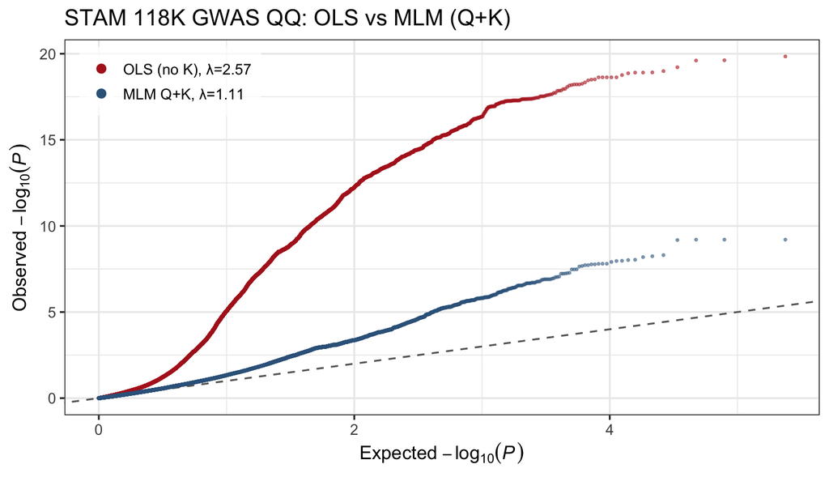

```r
qd <- two[, {
  p <- P[is.finite(P) & P > 0 & P <= 1]
  o <- -log10(sort(p))
  e <- -log10(ppoints(length(p)))
  k <- c(which(o > 2), sample(which(o <= 2), min(sum(o <= 2), 8000)))
  .(exp = e[k], obs = o[k])
}, by = mlab]
ggplot(qd, aes(exp, obs, colour = mlab)) +
  geom_abline(slope = 1, intercept = 0, colour = "grey40", linetype = "dashed") +
  geom_point(size = 0.5, alpha = 0.5) +
  scale_colour_manual(values = pal, name = NULL) +
  guides(colour = guide_legend(override.aes = list(size = 2.5, alpha = 1))) +
  labs(
    x = expression(Expected ~ -log[10](italic(P))), y = expression(Observed ~ -log[10](italic(P))),
    title = "STAM 118K GWAS QQ: OLS vs MLM (Q+K)"
  ) +
  theme(
    legend.position = c(0.02, 0.98), legend.justification = c(0, 1),
    legend.background = element_rect(fill = scales::alpha("white", 0.7), colour = NA)
  )
```

## Manhattan — OLS vs MLM (Q+K), scatter preserved

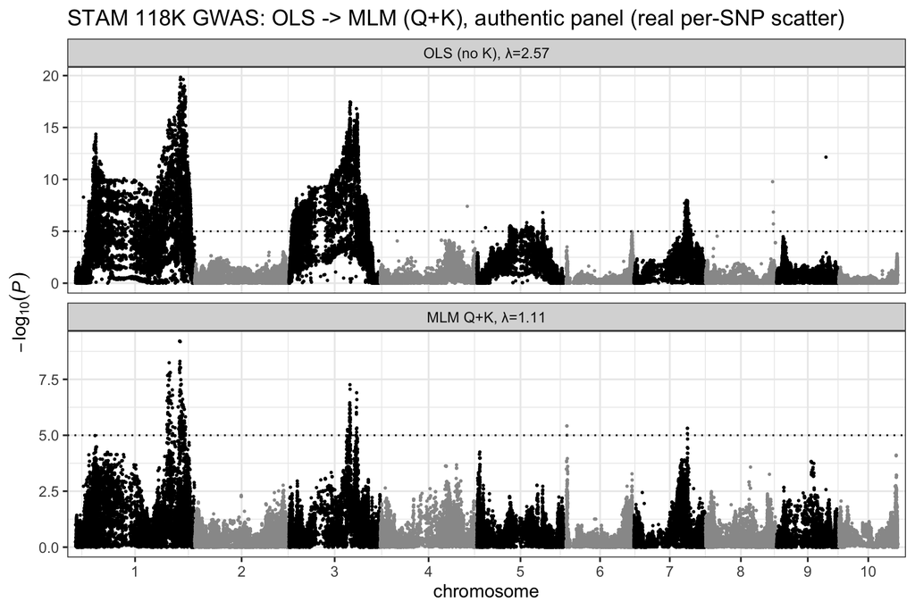

```r
off <- two[method == "OLS (no K)", .(mx = max(BP)), by = CHR][order(CHR)]
off[, base := cumsum(as.numeric(shift(mx, fill = 0)))]
m2 <- merge(two, off[, .(CHR, base)], by = "CHR")
m2[, `:=`(x = as.numeric(BP) + base, logP = -log10(P))]
axis <- m2[, .(mid = (min(x) + max(x)) / 2), by = CHR][order(CHR)]
ggplot(m2[order(CHR, BP)], aes(x, logP, colour = factor(CHR %% 2))) +
  geom_point(size = 0.35) +
  geom_hline(yintercept = LOD, linetype = "dotted") +
  facet_wrap(~mlab, ncol = 1, scales = "free_y") +
  scale_colour_manual(values = c("grey60", "black"), guide = "none") +
  scale_x_continuous(breaks = axis$mid, labels = axis$CHR, expand = c(0.01, 0)) +
  labs(
    x = "chromosome", y = expression(-log[10](italic(P))),
    title = "STAM 118K GWAS: OLS -> MLM (Q+K), authentic panel (real per-SNP scatter)"
  )
```

## Candidate-gene peaks: OLS vs MLM (±500 kb)

```r
ov <- fread(here("results/sim/teonam/stam_candidate_overlap.csv")) # symbol, chr, start (v5)
peakfn <- function(scan, ch, ps) {
  w <- scan[CHR == ch & abs(BP - ps) <= 5e5]
  if (nrow(w)) round(max(-log10(w$P)), 2) else NA_real_
}
gt <- data.table(
  gene = ov$symbol, chr = ov$chr,
  OLS = mapply(function(c, p) peakfn(ols, c, p), ov$chr, ov$start),
  MLM = mapply(function(c, p) peakfn(mlm, c, p), ov$chr, ov$start)
)
gt[, `OLS>5` := ifelse(is.finite(OLS) & OLS >= LOD, "yes", "no")]
gt[, `MLM>5` := ifelse(is.finite(MLM) & MLM >= LOD, "yes", "no")]
knitr::kable(gt[order(-OLS)], caption = "Candidate-gene peak -log10P (±500 kb): OLS vs MLM on the 118K panel, and LOD-5 survival.")
```

Candidate-gene peak -log10P (±500 kb): OLS vs MLM on the 118K panel, and LOD-5 survival.

| gene | chr | OLS | MLM | OLS>5 | MLM>5 |
| --- | --- | --- | --- | --- | --- |
| tb1 | 1 | 19.84 | 8.02 | yes | yes |
| zmm16 | 3 | 15.44 | 6.90 | yes | yes |
| tru1 | 3 | 14.18 | 5.25 | yes | yes |
| an1 | 1 | 12.14 | 4.18 | yes | no |
| ts2 | 1 | 11.62 | 3.72 | yes | no |
| tsh4 | 7 | 7.94 | 5.31 | yes | yes |

## Notes

- **Canonical, tracked source** for the 118K MLM: `scripts/teonam_mlm118k.R` (build → K → MLM). Outputs: `data/teonam/tassel/mlm_118k2.txt`, `results/sim/teonam/mlm_118k_timings.csv`.
- **No densification.** The 118K GWAS panel is ~2.7% missing, so the MLM runs on it directly (TASSEL handles per-site missing) — the Manhattan keeps its natural scatter. This is the faithful Fig-4C model that the interpolated 51K MLM notebook explicitly could not provide (it densified the 73%-missing map panel → plateau + over-correction).
- **Model still OLS-vs-MLM only.** The nested (family:marker) specification — Chen’s *primary* JLM — and the additive-only (1-df) vs joint (2-df) choice are the same open model-specification points discussed in the interpolated notebook; a LOCO over-correction diagnostic is not needed here (no interpolation pseudo-replication), and is left as optional future work.